# Escape-Room

Escape-Room is an exploration of hierarchical planning, commonsense reasoning, and spatial reasoning with Companions. We designed “escape room” challenges and designed a Companions agent to implement reasoning to solve the challenge. In these challenges, our agent is trapped in a room. In order to escape, the agent needs to fetch the key to unlock the door and escape the room. Various obstacles that the agent must overcome to escape the room include accessing keys underneath stacks of boxes, within jars, within multiple jars, and likewise for tools that may similarly be inaccessible, but are necessary to escape!.

## Description of Capabilities

This implementation was designed to model several aspects of intelligent reasoning: 1. Reasoning about spatial relations (on-relations and containment relations) and how they affect the ability to access an object 2. Recursive reasoning - Allows for flexibility in reasoning, so that the agent can carry out an unlimited number of steps without needing to know the entire plan in advance (i.e., the agent can work on accessing a hammer obscured in multiple ways until it is successful). 3. Common Sense Reasoning * Object Affordances - only certain objects can break jars, etc. * Accessibility - an object is not accessible if it is obscured in some way (e.g., something is on top of it, or it is contained by another object) * Planning the correct order of actions - An object can only be interacted with if it is accessible. For example, you can only move a box if it is clear on top. If you have several objects stacked on one another, they must be removed in a certain order (i.e., from top to bottom) 4. Generality - we attempted to model the entities, relations, and methods at a high level of generality, to allow for more flexibility in reasoning. For example: * Our system considers which tools to use to break a jar based on whether or not they are a PoundingDrivingInstrument[1], rather than based on specific instances like “Hammer.” * We tried to keep our methods for interacting with objects general as well. Through the use of only 8 methods and 5 horn clauses - our system is able to handle a wide variety of tasks, and can use the same methods to interact with different types of objects. Thus we attempted to avoid unintelligent (and psychologically-implausible) object-specific planning and action taking. 5. Executing the plan with the optimal number of steps - When multiple paths are available, the reasoner will choose the path that results in the optimal number of steps. If two different paths are equivalent, it will choose arbitrarily (which can sometimes result in some behavior that would be strange for humans - i.e., going for an obscured hammer before an accessible).

## Using with CogSketch

Our original intent was to have our reasoner be able to communicate with CogSketch, allowing the user to draw a novel level (within constraints), and have the reasoner be able to solve that new level. Unfortunately, we couldn’t figure out how to get the two to interface. But, as discussed above, we did attempt to write our code at a level of generality that would make future interface with CogSketch easy. We invite anyone who is able to connect the two to give it a try.

## Overview of Files

Escape-Room consists of: 1. EscapeMt, which defines methods for solving the challenges. 2. EscapeOntologyMt, which initializes the methods. 3. Six “levels,” which each contain a microtheory that contain facts that represent a challenge that the agent must solve. In each level, the agent must fetch the key to escape from the room.

## Usage

1. Download each of the krf files and start a companion.
2. Run (doClearWorkingMemory).
3. Use “Load Flatfile” in session-reasoner to load EscapeMt, EscapeOntologyMt, and LevelOneMt.
4. Run (fetch K1 LevelOneMt)
5. Search MyEscapePlanMt in the knowledge base to see the agent’s actions in this level.
6. If you want to run the next level, first run (doClearWorkingMemory) and (doForgetKBMt MyEscapePlanMt)
7. Load the level you want to run next as a flatfile.
8. Run (fetch K1 < mt-name >) where < mt-name > is the level you want to run. Repeat steps 5-8 for the rest of the levels.
9. IMPORTANT: If you wish to run a certain level more than once, in between each run you must forget the level microtheory and reload the flatfile.

# Levels

### Level 1

There is a key on top of the box. The agent fetches the key and escapes the room.

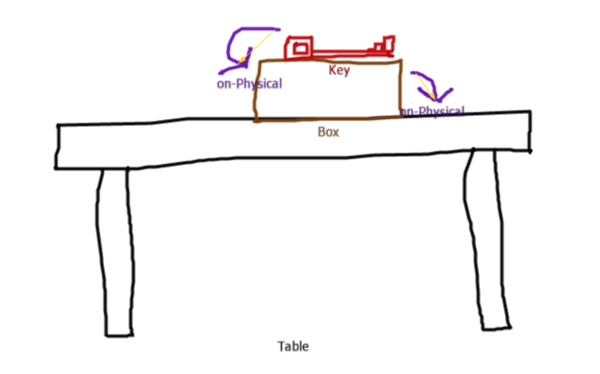

### Level 2

The key is in a jar on a table. There is also a hammer on the table. The agent fetches the hammer, breaks the jar, fetches the key and escapes the room.

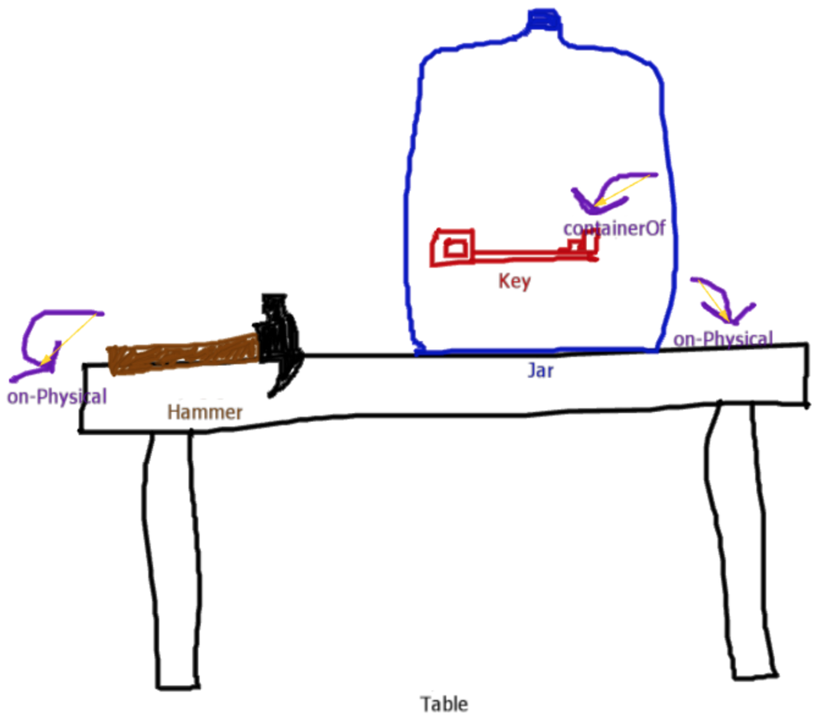

### Level 3

The key is on a table, but there a three boxes on top of it. The agent removes the top box, and then removes the box that was underneath it, then removes the last box on top of the key. Then the agent fetches the key and escapes the room.

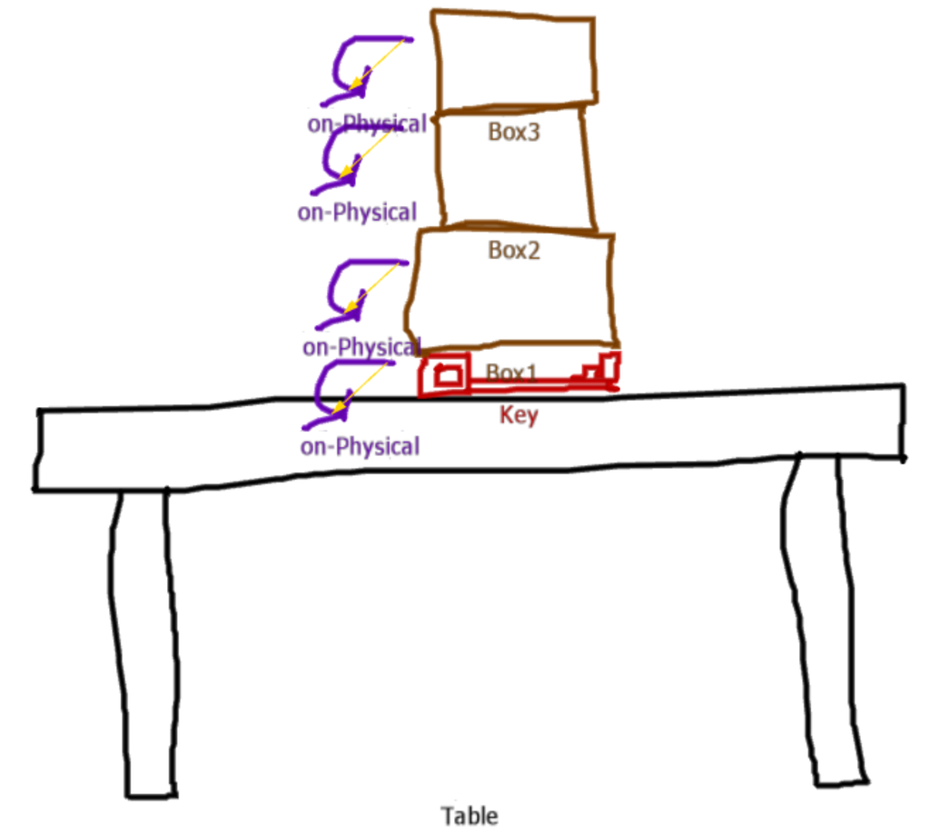

### Level 4

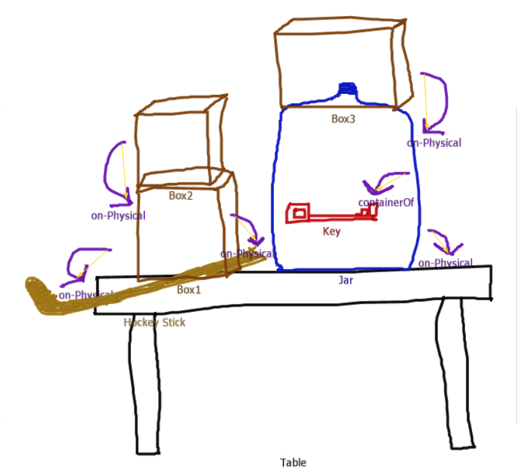

### Level 5

There is a jar on the table which contains another jar. The inner jar contains the key. There is a box on top of the jar. There are two hammers on the table. One of the hammers has two boxes on it. The agent takes the box off the jar. Then the agent fetches the uncovered hammer and smashes the outer jar. The hammer breaks in the process. The agent takes each box off the covered hammer, fetches it, and uses it to break the inner jar. The agent fetches the key and escapes the room.

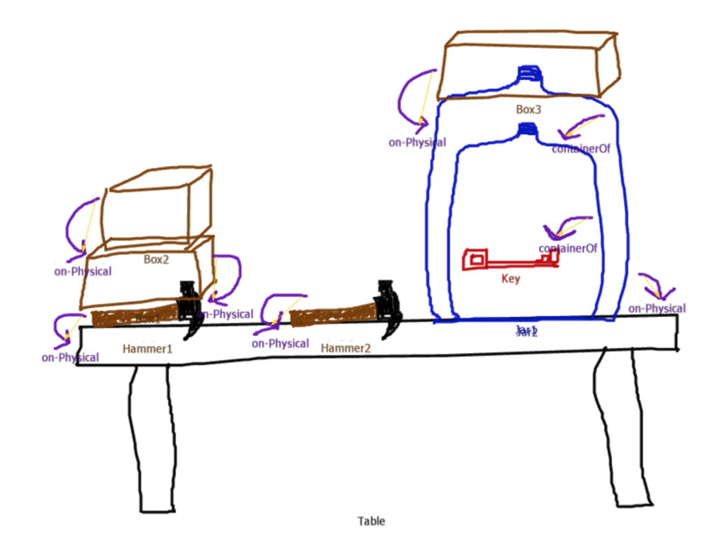

### Level 6

There are two jars on the table. One has a key in it, and one has a hammer in it. The jar containing a key has one box on it, and the jar containing a hammer has two boxes on it. There is also a hammer on the table. The agent takes the box off of the jar containing a key. It uses the uncovered hammer to break the jar. The agent fetches the key and escapes the room. This level demonstrates that the agent ignores the chance to smash open the second jar, and instead takes the most straightforward path to achieving its goal.

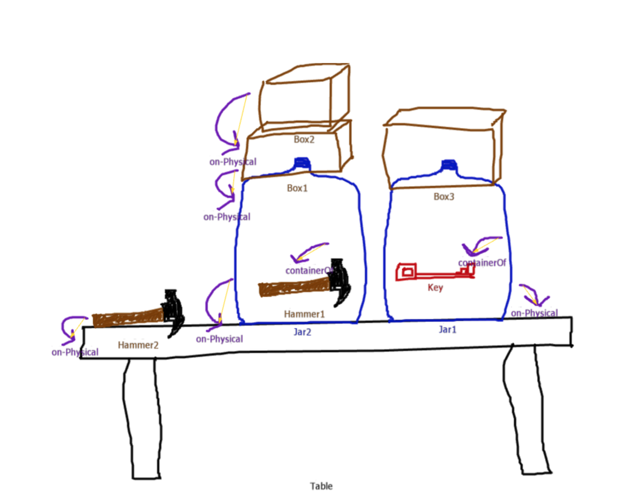